# Biking in the Rain: An Analysis of Temperature on the Bikeshare Business with ARIMA

Renee Aziz, Lauren Seib, and Manuella de Carvalho Rodrigues

2024-05-01

# 1 Purpose

Capital Bikeshare is a bikeshare company located in Washington D.C.

The purpose of this project is to analyze the dataset below, which ranges from 2011 to 2012, to see how temperature affects the number of registered users.

Ultimately, this will allow Capital Bikeshare and other bikeshare companies in D.C. to think about when is the best time to market their business.

Data reference: [**Bike Sharing Dataset on Kaggle**](https://www.kaggle.com/datasets/marklvl/bike-sharing-dataset)

## 1.1 Objectives

Reading the .csv files from Capital Bikeshare, a bikesharing company in Washington D.C., there is an apparent discrepancy between casual users, users that use the service minimally, and registered users, users that have an account with Capital Bikeshare. As business analytics majors, analyzing business conditions is our passion. We would like to tackle the question of how to turn more of these casual users into registered users through targeted marketing.

Capital Bikeshare’s data set has different variables relating to time and weather. We will not aim to establish which variables cause an increase or decrease in users, but we can hypothesize correlations between variables and changes in the number of registered users.

In addition, we will be using the Readme.txt data dictionary to understand the data from day.csv. We decided to omit hour.csv from our analysis since we think that the hourly data will be too specific for a marketing plan. It is better to analyze trends on a macro level than on a micro level by hour to generate feasible months or weeks to advertise, not hours. We think that overall trends and correlations on a seasonal basis that change daily is much more indicative of a better marketing plan.

We anticipate that correlations we find between the time and the weather might apply to other demographics as well despite differences in location and culture. These results will help identify possible correlations between the weather and the number of registered users, and this is exactly what these companies need for their marketing campaigns.

## 1.2 Data Preprocessing

```r
library(tidyverse) # creating tidy data
library(dplyr)     # transforming data
library(ggplot2)   # visualizing data
library(forecast)
library(car)
```

## 1.3 Data Preparation and Manipulation

### 1.3.1 Data Understanding

Capital Bikeshare in Washington D.C., USA, incorporated the bike share data set to monitor and predict the amount of bike rental counts hourly and daily based on the environmental and seasonal factors. They collected the information every day from 2011 to 2012 while users rented the bikes for use.

The data that we will be focusing on in our exploratory analysis is bike shares on a daily basis, which provides 16 potential variables in this data set. While the data set does not have any missing values, one irregularity in the data set is that the data type of the variable ’dteday” is as a character. In addition, another peculiarity is that the data dictionary for this data set incorrectly identifies the seasons. The data dictionary in Readme.txt specifies that 1 is spring, 2 is summer, 3 is fall, and 4 is winter. However, we can see that season 1 is from Jan to Mar 20, season 2 is from Mar 21 to June 20, season 3 is from June 21 to Sep 22, and season 4 is from Sep 23 to Dec 20, until 1 repeats again till the end of the year. I observed this in the year 2011, and just with a quick look at 2012, the cutoff dates for the season are quite similar. Because these dates reflect the seasons in Washington D.C., we know that the date ranges imply that 1 as winter, 2 as spring, 3 as summer, and 4 as fall instead of the season classifications that the data dictionary implies.

### 1.3.2 Data Import and Cleaning

We are downloading the day.csv data set and placing it into the data folder. We will then run the following code to import day.csv to the variable ‘bike_share’ and view the first 10 rows in the data set for familiarity. We are also going to use the str() function to become familiar with the data types of the variables and the type of variables available. In addition, we used the is.na() function in colSums() to check if there are any missing values in the data set.

```r
## Usually, if given the link to the file, we would link the file in the
## read.csv function. Since this data is from Kaggle, we downloaded it into a
## folder called "data". We are importing the data here:

getwd()
```

```
## [1] "G:/My Drive/Predictive Analytics Group"
```

```r
bike_share <- read.csv('./data/day.csv')
head(bike_share, 10)
```

```
##    instant     dteday season yr mnth holiday weekday workingday weathersit
## 1        1 2011-01-01      1  0    1       0       6          0          2
## 2        2 2011-01-02      1  0    1       0       0          0          2
## 3        3 2011-01-03      1  0    1       0       1          1          1
## 4        4 2011-01-04      1  0    1       0       2          1          1
## 5        5 2011-01-05      1  0    1       0       3          1          1
## 6        6 2011-01-06      1  0    1       0       4          1          1
## 7        7 2011-01-07      1  0    1       0       5          1          2
## 8        8 2011-01-08      1  0    1       0       6          0          2
## 9        9 2011-01-09      1  0    1       0       0          0          1
## 10      10 2011-01-10      1  0    1       0       1          1          1
##        temp    atemp      hum windspeed casual registered  cnt
## 1  0.344167 0.363625 0.805833 0.1604460    331        654  985
## 2  0.363478 0.353739 0.696087 0.2485390    131        670  801
## 3  0.196364 0.189405 0.437273 0.2483090    120       1229 1349
## 4  0.200000 0.212122 0.590435 0.1602960    108       1454 1562
## 5  0.226957 0.229270 0.436957 0.1869000     82       1518 1600
## 6  0.204348 0.233209 0.518261 0.0895652     88       1518 1606
## 7  0.196522 0.208839 0.498696 0.1687260    148       1362 1510
## 8  0.165000 0.162254 0.535833 0.2668040     68        891  959
## 9  0.138333 0.116175 0.434167 0.3619500     54        768  822
## 10 0.150833 0.150888 0.482917 0.2232670     41       1280 1321
```

```r
## Here, we use str() to become more familiar with the data set.
str(bike_share)
```

```
## 'data.frame':    731 obs. of  16 variables:
##  $ instant   : int  1 2 3 4 5 6 7 8 9 10 ...
##  $ dteday    : chr  "2011-01-01" "2011-01-02" "2011-01-03" "2011-01-04" ...
##  $ season    : int  1 1 1 1 1 1 1 1 1 1 ...
##  $ yr        : int  0 0 0 0 0 0 0 0 0 0 ...
##  $ mnth      : int  1 1 1 1 1 1 1 1 1 1 ...
##  $ holiday   : int  0 0 0 0 0 0 0 0 0 0 ...
##  $ weekday   : int  6 0 1 2 3 4 5 6 0 1 ...
##  $ workingday: int  0 0 1 1 1 1 1 0 0 1 ...
##  $ weathersit: int  2 2 1 1 1 1 2 2 1 1 ...
##  $ temp      : num  0.344 0.363 0.196 0.2 0.227 ...
##  $ atemp     : num  0.364 0.354 0.189 0.212 0.229 ...
##  $ hum       : num  0.806 0.696 0.437 0.59 0.437 ...
##  $ windspeed : num  0.16 0.249 0.248 0.16 0.187 ...
##  $ casual    : int  331 131 120 108 82 88 148 68 54 41 ...
##  $ registered: int  654 670 1229 1454 1518 1518 1362 891 768 1280 ...
##  $ cnt       : int  985 801 1349 1562 1600 1606 1510 959 822 1321 ...
```

```r
## Making sure there are no missing values, just in case.
missing_val <- colSums(is.na(bike_share))
missing_val
```

```
##    instant     dteday     season         yr       mnth    holiday    weekday
##          0          0          0          0          0          0          0
## workingday weathersit       temp      atemp        hum  windspeed     casual
##          0          0          0          0          0          0          0
## registered        cnt
##          0          0
```

Next, we will clean up the data set. We will first remove the variable columns that are irrelevant to our project and assign new names to the remaining columns of the dataframe for clarity. It is imperative to keep in mind our purpose: to figure out why the number of registered users decreases. We thus decided on keeping the following variables:

#### 1.3.2.1 Useful Variables

**dteday** Although we do not directly use the date in our analysis, if we wanted to conduct further analysis on the data between a range of dates (e.g., to analyze the impact of an event on registered vs. casual users), then this variable would be essential.

**season** We would like to see the effects of the season on the number of registered users. It’s possible that a variable associated with season would be more interesting to analyze, however.

**mnth** It would be interesting to see variation by month instead of just season. This would help us be more specific in our time-series analysis.

**holiday** Just thinking about a marketing strategy, we know that consumer behavior differs on holidays, especially in regards to transportation, when it comes to time taken off of work for leisure or to spend time with family.

**weathersit** This variable reports precipitation or weather conditions that would affect bikers like mist, snow, rain, clouds, etc. This is instrumental in analyzing increases and decreases in registered users for this bikeshare service due to utility and demand when the weather is not ideal for biking.

**casual** This variable reports the number of casual users. It would be intriguing to analyze increases and decreases in respect to the number of registered users.

**registered** This variable reports the number of registered users which is what our analysis is based upon.

**weekday and workingday** We think that this reveals a lot about weekly cycles. Weekday is the day of the week ranging from 0 (Sunday) to 6 (Saturday). Workingday is if the day is not a weekend nor a holiday (1) or not (0).

#### 1.3.2.2 Variables We Omitted

**instant** This variable is the index, but our unique key in the data set is the date the length of the data set is the length of the unique values in the date.

**yr** We already have the date, so this variable is futile.

**cnt** This is the total number of casual and registered users. We ended up omitting this variable because it is simply the addition of variables **registered** and **casual**.

After a data type analysis, the only column that requires modification is the date column because changing it to a date type will allow us to potentially conduct analysis on a range of dates.

```r
## Select the dataframe to display only the column names 'dteday', 'season',
## 'mnth', 'holiday', 'weathersit', 'casual', 'registered'
bike_share <- select(bike_share, dteday, season, mnth, holiday, weekday, workingday, weathersit, temp, atemp, hum, windspeed,
                          casual, registered)
## Rename the columns for ease of understanding so that someone unfamiliar with
## the data set will understand the  variable names. We looked at the data
## dictionary to aid us with this.
colnames(bike_share) <- c("date", "season", "month", "holiday", "weekday", "workingday", "weather", "temperature", "felt_temperature", "humidity", "windspeed",
                               "casual", "registered")
```

### 1.3.3 Cleaned Data Presentation

```r
head(bike_share, 10)
```

```
##          date season month holiday weekday workingday weather temperature
## 1  2011-01-01      1     1       0       6          0       2    0.344167
## 2  2011-01-02      1     1       0       0          0       2    0.363478
## 3  2011-01-03      1     1       0       1          1       1    0.196364
## 4  2011-01-04      1     1       0       2          1       1    0.200000
## 5  2011-01-05      1     1       0       3          1       1    0.226957
## 6  2011-01-06      1     1       0       4          1       1    0.204348
## 7  2011-01-07      1     1       0       5          1       2    0.196522
## 8  2011-01-08      1     1       0       6          0       2    0.165000
## 9  2011-01-09      1     1       0       0          0       1    0.138333
## 10 2011-01-10      1     1       0       1          1       1    0.150833
##    felt_temperature humidity windspeed casual registered
## 1          0.363625 0.805833 0.1604460    331        654
## 2          0.353739 0.696087 0.2485390    131        670
## 3          0.189405 0.437273 0.2483090    120       1229
## 4          0.212122 0.590435 0.1602960    108       1454
## 5          0.229270 0.436957 0.1869000     82       1518
## 6          0.233209 0.518261 0.0895652     88       1518
## 7          0.208839 0.498696 0.1687260    148       1362
## 8          0.162254 0.535833 0.2668040     68        891
## 9          0.116175 0.434167 0.3619500     54        768
## 10         0.150888 0.482917 0.2232670     41       1280
```

## 1.4 Exploratory Data Analysis

### 1.4.1 Variable Summary

#### 1.4.1.1 Overview

- `date`: Date of the record (character)
- `season`: Season of the year (integer)
- `month`: Month of the year (integer)
- `holiday`: Indicator of holiday (integer)
- `weekday`: Day of the week (integer)
- `workingday`: Whether or not it’s a working day (integer)
- `weather`: Weather situation (integer)
- `temperature` : Normalized temperature in Celsius. The values are divided to 41 (max) (double)
- `felt_temperature`: Normalized feeling temperature in Celsius. The values are divided to 50 (max) (double)
- `humidity`: Normalized humidity. The values are divided to 100 (max) (double)
- `windspeed`: Normalized wind speed. The values are divided to 67 (max) (double)
- `casual`: Number of casual bike rentals (integer)
- `registered`: Number of registered bike rentals (integer)

### 1.4.2 Correlation

Here, we decided to do a correlation to get a feel for possible correlations or multicorrelations between the variables.

```r
# Compute correlation matrix
cor_users <- cor(bike_share[c("season", "month", "holiday", "weekday", "workingday", "weather", "temperature", "felt_temperature", "humidity", "windspeed", "casual",
                               "registered")])

# Print correlation matrices
print("Correlation Matrix for users:")
```

```
## [1] "Correlation Matrix for users:"
```

```r
print(cor_users)
```

```
##                        season        month      holiday       weekday
## season            1.000000000  0.831440114 -0.010536659 -0.0030798813
## month             0.831440114  1.000000000  0.019190895  0.0095093129
## holiday          -0.010536659  0.019190895  1.000000000 -0.1019602689
## weekday          -0.003079881  0.009509313 -0.101960269  1.0000000000
## workingday        0.012484963 -0.005900951 -0.253022700  0.0357896736
## weather           0.019211028  0.043528098 -0.034626841  0.0310874694
## temperature       0.334314856  0.220205335 -0.028555535 -0.0001699624
## felt_temperature  0.342875613  0.227458630 -0.032506692 -0.0075371318
## humidity          0.205444765  0.222203691 -0.015937479 -0.0522321004
## windspeed        -0.229046337 -0.207501752  0.006291507  0.0142821241
## casual            0.210399165  0.123005889  0.054274203  0.0599226375
## registered        0.411623051  0.293487830 -0.108744863  0.0573674440
##                    workingday     weather   temperature felt_temperature
## season            0.012484963  0.01921103  0.3343148564      0.342875613
## month            -0.005900951  0.04352810  0.2202053352      0.227458630
## holiday          -0.253022700 -0.03462684 -0.0285555350     -0.032506692
## weekday           0.035789674  0.03108747 -0.0001699624     -0.007537132
## workingday        1.000000000  0.06120043  0.0526598102      0.052182275
## weather           0.061200430  1.00000000 -0.1206022365     -0.121583354
## temperature       0.052659810 -0.12060224  1.0000000000      0.991701553
## felt_temperature  0.052182275 -0.12158335  0.9917015532      1.000000000
## humidity          0.024327046  0.59104460  0.1269629390      0.139988060
## windspeed        -0.018796487  0.03951106 -0.1579441204     -0.183642967
## casual           -0.518044191 -0.24735300  0.5432846617      0.543863690
## registered        0.303907117 -0.26038771  0.5400119662      0.544191758
##                     humidity    windspeed      casual  registered
## season            0.20544476 -0.229046337  0.21039916  0.41162305
## month             0.22220369 -0.207501752  0.12300589  0.29348783
## holiday          -0.01593748  0.006291507  0.05427420 -0.10874486
## weekday          -0.05223210  0.014282124  0.05992264  0.05736744
## workingday        0.02432705 -0.018796487 -0.51804419  0.30390712
## weather           0.59104460  0.039511059 -0.24735300 -0.26038771
## temperature       0.12696294 -0.157944120  0.54328466  0.54001197
## felt_temperature  0.13998806 -0.183642967  0.54386369  0.54419176
## humidity          1.00000000 -0.248489099 -0.07700788 -0.09108860
## windspeed        -0.24848910  1.000000000 -0.16761335 -0.21744898
## casual           -0.07700788 -0.167613349  1.00000000  0.39528245
## registered       -0.09108860 -0.217448981  0.39528245  1.00000000
```

```r
# Compute correlation and its p-value between 'temperature' and 'registered'
cor_test_result <- cor.test(bike_share$temperature, bike_share$registered)

# Extract correlation coefficient and p-value
correlation <- cor_test_result$estimate
p_value <- cor_test_result$p.value

# Print the correlation coefficient and p-value
print(paste("Correlation between Temperature and Registered Users:", correlation))
```

```
## [1] "Correlation between Temperature and Registered Users: 0.540011966161786"
```

```r
print(paste("P-value:", p_value))
```

```
## [1] "P-value: 1.44622865127018e-56"
```

Conclusions:

Next, we generated two data frames: one, named “registered_lt_mean,” which will select dates with relatively low registered bike user counts, and the second, named “casual_gt_mean,” which will select dates with relatively high casual user counts.

```r
## Filter dates where the amount of registered bike users is less than the
## average amount of daily registered users
reg_lt_mean <- filter(bike_share,
                       registered < mean(bike_share$registered))
## Filter dates where the amount of casuals bike users is greater than the
## average amount of daily registered users
casual_gt_mean <- filter(bike_share,
                       casual > mean(bike_share$casual))
```

Then, we created a function that allows us to view the percentage of bike users, in terms of different variables (season, holiday, and weather) in comparison to the overall occurrence percentage of these variables in the original data set. By calculating and comparing these percentages, we aim to identify any patterns in bike usage behavior.

```r
## Create a function that calculates the percentage of the occurrences in their
## respective dataframe
avg_perc_func <- function(data, column, conditions) {
  results <- vector(mode = "numeric",
                    length = length(conditions))
  for (i in seq_along(conditions)) {
    condition <- conditions[i]
    filter <- data[data[[column]] == condition, ]
    results[i] <- round(nrow(filter)/nrow(data) * 100, digits = 2)
  }
  return(results)
}

# Function to calculate percentage comparison
calc_comp <- function(data, column, category) {
  avg_perc <- avg_perc_func(data, column, category)
  paste(avg_perc)
}

# Create a new data frame for registered bike users that include the different
# categories (Season, Holiday, and Weather) and the percentage of registered
# bike users
reg_data <- data.frame(
  Category = c("Season", "Season", "Season", "Season", "Holiday", "Holiday",
               "Weather", "Weather", "Weather", "Weather"),
  Type = c("Winter", "Spring", "Summer", "Fall", "Holiday", "Non-holiday",
           "Clear/Cloudy", "Misty", "Light Snow", "Heavy Rain"),
  Avg_Perc_Registered = c(
    avg_perc_func(reg_lt_mean, "season", 1), avg_perc_func(reg_lt_mean,
                                                           "season", 2),
    avg_perc_func(reg_lt_mean, "season", 3), avg_perc_func(reg_lt_mean,
                                                           "season", 4),
    avg_perc_func(reg_lt_mean, "holiday", 1), avg_perc_func(reg_lt_mean,
                                                            "holiday", 0),
    avg_perc_func(reg_lt_mean, "weather", 1), avg_perc_func(reg_lt_mean,
                                                            "weather", 2),
    avg_perc_func(reg_lt_mean, "weather", 3), avg_perc_func(reg_lt_mean,
                                                            "weather", 4)
  )
)

# Add a new column that calculates the percentage of occurrence of each category
# in the entire `bikeshare` data set for comparison
reg_data$Overall_Perc_Occurrence <- c(
  calc_comp(bike_share, "season", 1), calc_comp(bike_share, "season", 2),
  calc_comp(bike_share, "season", 3), calc_comp(bike_share, "season", 4),
  calc_comp(bike_share, "holiday", 1), calc_comp(bike_share, "holiday", 0),
  calc_comp(bike_share, "weather", 1), calc_comp(bike_share, "weather", 2),
  calc_comp(bike_share, "weather", 3), calc_comp(bike_share, "weather", 4)
)
```

Here is a comparison of the average percentage of days when *registered users* is less than the average number of registered users from 2011 to 2012 in comparison to the overall occurrence overall occurrence percentage of these variables in the original data set:

```r
print(reg_data)
```

```
##    Category         Type Avg_Perc_Registered Overall_Perc_Occurrence
## 1    Season       Winter               41.21                   24.76
## 2    Season       Spring               21.70                   25.17
## 3    Season       Summer               15.38                   25.72
## 4    Season         Fall               21.70                   24.35
## 5   Holiday      Holiday                4.40                    2.87
## 6   Holiday  Non-holiday               95.60                   97.13
## 7   Weather Clear/Cloudy               53.85                   63.34
## 8   Weather        Misty               40.66                   33.79
## 9   Weather   Light Snow                5.49                    2.87
## 10  Weather   Heavy Rain                0.00                       0
```

The comparison is important because if the percentage of occurrence in the filtered dataframe is greater than the percentage of occurrence in the original dataframe, this may signify that there is some sort of correlation between that environmental or seasonal factor to the amount of registered/casual bike users on a given day. However, it’s important to acknowledge that *further* research should be performed, like performing a t-test to ensure that these values are actually statistically significant.

After analyzing these comparisons, we noticed that the percentage of low registered users in the winter is 41.21 % which is greater than the overall occurrence percentage of winter days, which is only 24.76 %. This means that the winter season may be a factor that can affect low registered users.

Furthermore, the percentage of low registered users during the holidays is another disparity that stands out. Among the days with proportionately fewer registered bike users, 4.4 % occurred during holidays, whereas holidays comprised only 2.87 % of the total observed days.

In our next visualization, we made a comparative line plot to determine the differences in the number of registered and casual users by day. We can see that sometimes, when registered goes up, casual goes down. This happens repeatedly throughout the graph and is a sign that we cannot combine the two.

```r
# Calculate max value for y-axis
max_value <- max(max(bike_share$registered), max(bike_share$casual))

# Convert bike_share$date to datetime if needed
bike_share$date <- as.Date(bike_share$date)

# Check for missing or invalid values in bike_share$date
# Remove rows with missing or invalid dates if necessary
bike_share <- bike_share[!is.na(bike_share$date), ]

# Set the plot dimensions and adjust axis text size
par(mar = c(5, 4, 4, 2), cex.axis = 0.8) # Adjust the bottom margin and axis text size

# Plot for registered users by day
plot(bike_share$date, bike_share$registered,
     type = "l", col = "blue",
     xlab = "Day", ylab = "Bike Users",
     main = "Registered vs Casual Bike Rentals by Day",
     ylim = c(0, max_value),
     xaxt = "n")

# Plot for mean casual users by month
lines(bike_share$date, bike_share$casual,
      type = "l", col = "red")

# Set x-axis labels by month and year
axis(1, at = bike_share$date, labels = bike_share$month_year, las = 2) # las = 2 for vertical labels

# Set x-axis limits manually (if needed)
xlim_start <- as.Date("2022-01-01") # Replace with your desired start date
xlim_end <- as.Date("2022-12-31") # Replace with your desired end date
xlim(xlim_start, xlim_end)
```

```
## <ScaleContinuousDate>
##  Range:
##  Limits: 1.9e+04 -- 1.94e+04
```

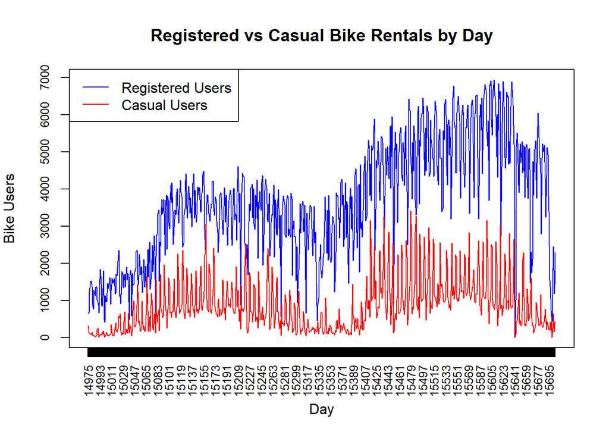

```r
# Add legends to identify the two graphs
legend("topleft", legend = c("Registered Users", "Casual Users"),
       col = c("blue", "red"), lty = 1)
```

### 1.4.4 Violin Plot: The distribution of users by season

In addition, we think that a violin plot with a box plot in the middle would be an excellent way to show the distribution of registered users per season while also showing the interquartile ranges and the median. The frequency of the registered and casual users show where the count for registered and count were the most repeated per day. So the median and interquartile ranges would reflect where the user count remained for the most time over the two years: 2011 and 2012.

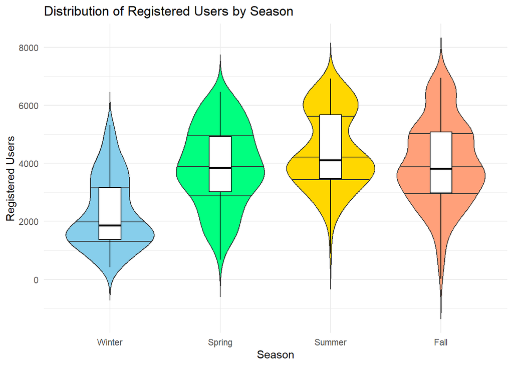

```r
# Create a longer dataframe that creates a column name user_type with values
# 'casual' and 'registered' users
bike_share_long <- bike_share %>%
  pivot_longer(cols = c("casual", "registered"), names_to = "user_type",
               values_to = "value")

# Plot the distribution of registered users, by season
bike_share %>%
  ggplot(aes(x = factor(season, levels = 1:4, labels = c("Winter", "Spring",
                                                         "Summer", "Fall")),
             y = registered,
             fill = factor(season, levels = 1:4, labels = c("Winter", "Spring",
                                                            "Summer", "Fall")))) +
  geom_violin(draw_quantiles = c(0.25, 0.5, 0.75), scale = "width", width = 0.8,
              trim = FALSE) +
  geom_boxplot(width = 0.2, fill = "white", color = "black", outlier.shape = NA) +
  scale_fill_manual(values = c("#87CEEB", "#00FF7F", "#FFD700", "#FFA07A")) +
  theme_minimal() +
  labs(x = "Season", y = "Registered Users") +
  ggtitle("Distribution of Registered Users by Season") +
  theme(legend.position = "none")
```

Ultimately, the seasons don’t really have a skew, rather a bimodal distribution when it comes to registered users. However, the casual users appear to have a skew.

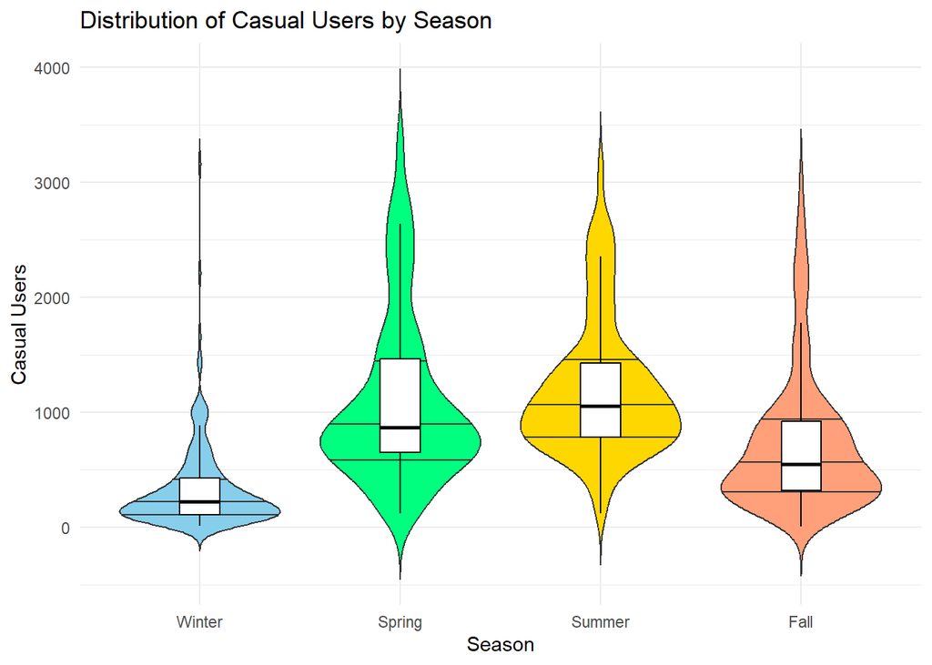

```r
# Plot the distribution of casual users, by season
bike_share %>%
  ggplot(aes(x = factor(season, labels = c("Winter", "Spring", "Summer", "Fall")),
             y = casual,
             fill = factor(season, labels = c("Winter", "Spring", "Summer",
                                              "Fall")))) +
  geom_violin(draw_quantiles = c(0.25, 0.5, 0.75), scale = "width", width = 0.8,
              trim = FALSE) +
  geom_boxplot(width = 0.2, fill = "white", color = "black", outlier.shape = NA) +
  scale_fill_manual(values = c("#87CEEB", "#00FF7F", "#FFD700", "#FFA07A")) +
  theme_minimal() +
  labs(x = "Season", y = "Casual Users") +
  ggtitle("Distribution of Casual Users by Season") +
  theme(legend.position = "none")
```

We can see that these values are skewed towards the bottom, meaning the median is toward the bottom. This is why we cannot sum the count of users together, the casual and registered, because their skews are different.

#### 1.4.4.1 Weather

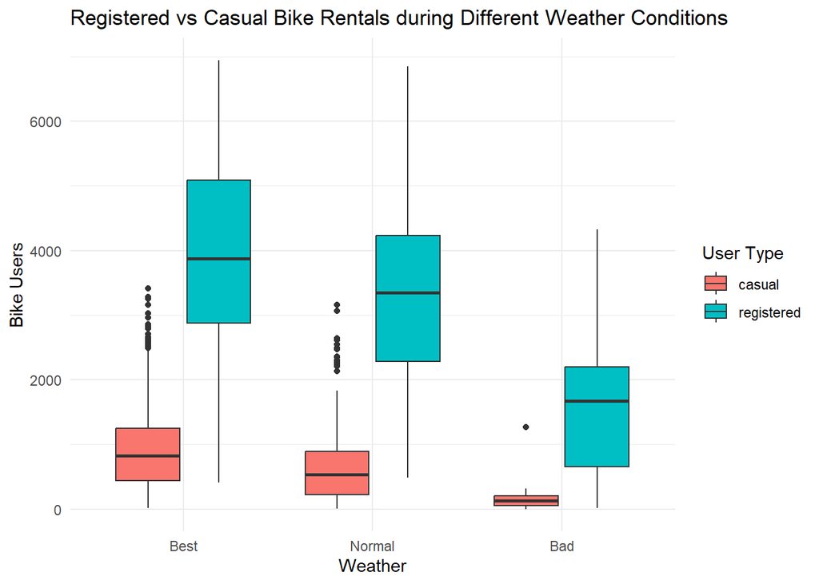

```r
ggplot(bike_share_long, aes(x = as.factor(weather), y = value, fill = user_type)) +
  geom_boxplot() +
  labs(title = "Registered vs Casual Bike Rentals during Different Weather Conditions",
       x = "Weather",
       y = "Bike Users",
       fill = "User Type") +
  theme_minimal() +
  scale_x_discrete(labels = c("Best", "Normal", "Bad"))
```

Here, we can also see that there is a bottom skew for the causal users once again. The weather variable is correlated with `temperature`, `felt_temperature`, `humidity`, and `windspeed`.  
More exploratory data analysis can be conducted with these variables. However, we have decided to assume that they would be similar to the results of the weather variable above. If our assumption is wrong, we will disclose this through our process of detrending. They are also not split up into few groups like `weather` above to analyse.

We can also see that there are **outliers** where the dots are for casual users. This signifies an unpredictable jump outside of the normal interquartile ranges for this number, and they’re always in the positive direction. However, we are retainin these outliers because they’re not so irrational that they’re unbelievable or miraculous. They are also only part of the casual data, which we will not be using.

### 1.4.5 Discussion and Conclusion: Our Hypothesis

In conclusion, we can see that there is clear skew differences between the casual user and registered user data, and there is plenty of seasonality, detrending, and cyclicality to explore.

Ultimately, we are deciding to focus on registered users since we cannot analyze registered and casual in one call, and the registered users generate more users due to being more signups and subscriptions. All of the above are assumptions. As we progress through a rigorous statistical process, we will see whether or not we can make the above hypotheses and see whether temperature/weather/related variables have an effect on registered users.

## 1.5 Model Selection: ARIMA

Once again, we picked the bikeshare data from 2011 to 2012 in Washington D.C. This was data recorred by and through a bikeshare company called Capital Bikeshare.

One urgent thought we had was that if the number of registered users on one day affects the number of registered users on another day. In this manner, we thought that ARIMA would be appropriate to run.

Data reference: [**Bike Sharing Dataset on Kaggle**](https://www.kaggle.com/datasets/marklvl/bike-sharing-dataset)

### 1.5.1 Reclean Dataset

Here, we reclean the dataset into a different bikeshare dataset so that we don’t confuse it with the original.

```r
## Select the dataframe to display only the column names 'dteday', 'season',
## 'mnth', 'holiday', 'weathersit', 'casual', 'registered'
bike_share2 <- read.csv('./data/day.csv')
bike_share3 <- select(bike_share2, dteday, season, mnth, holiday, weekday, workingday, weathersit, temp, atemp, hum, windspeed,
                          casual, registered, cnt)
## Rename the columns for ease of understanding so that someone unfamiliar with
## the data set will understand the  variable names. We looked at the data
## dictionary to aid us with this.
colnames(bike_share3) <- c("date", "season", "month", "holiday", "weekday", "workingday", "weather", "temperature", "felt_temperature", "humidity", "windspeed",
                               "casual", "registered", "count")

dataset_bike_share <-bike_share3[1:731,]
```

### 1.5.2 Create a Time Series Variable

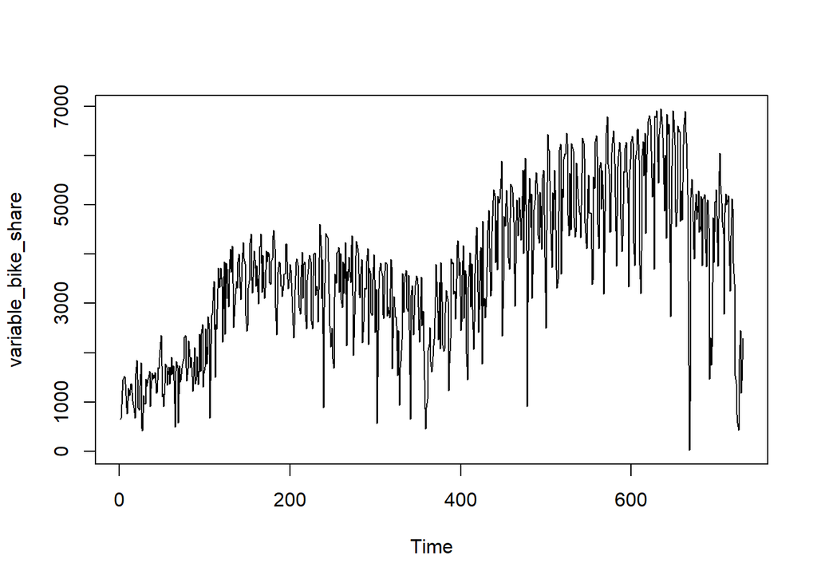

```r
variable_bike_share <- ts(dataset_bike_share$registered)
plot(variable_bike_share)
```

```r
head(variable_bike_share)
```

```
## Time Series:
## Start = 1
## End = 6
## Frequency = 1
## [1]  654  670 1229 1454 1518 1518
```

From this model, we can see that as time passes (representing days - 365 in a year and 731 from 2011 to 2012), The count of registered users also changes.

### 1.5.3 Detrending

From here on out in the report, a lot of explanations will be in code comments

```r
# Fit a linear trend model using tslm function
Model0 <- tslm(variable_bike_share ~ trend)
# Print the summary of the linear trend model
print(summary(Model0))
```

```
##
## Call:
## tslm(formula = variable_bike_share ~ trend)
##
## Residuals:
##     Min      1Q  Median      3Q     Max
## -5108.1  -659.2    48.8   906.8  2129.8
##
## Coefficients:
##              Estimate Std. Error t value Pr(>|t|)
## (Intercept) 1872.3601    86.8952   21.55   <2e-16 ***
## trend          4.8738     0.2057   23.70   <2e-16 ***
## ---
## Signif. codes:  0 '***' 0.001 '**' 0.01 '*' 0.05 '.' 0.1 ' ' 1
##
## Residual standard error: 1173 on 729 degrees of freedom
## Multiple R-squared:  0.4351, Adjusted R-squared:  0.4343
## F-statistic: 561.5 on 1 and 729 DF,  p-value: < 2.2e-16
```

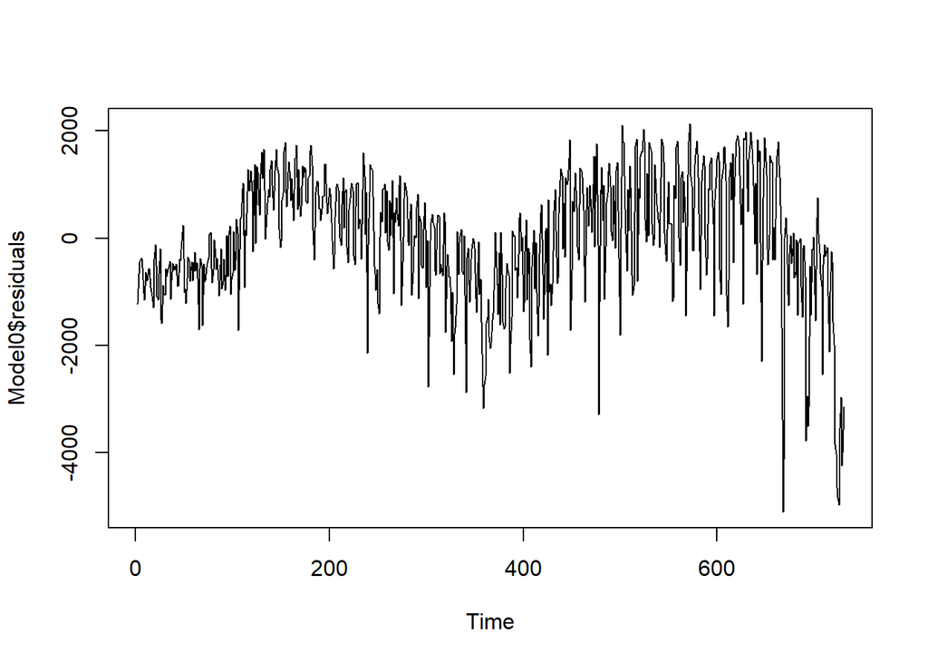

```r
# Plot the residuals of the linear trend model
plot(Model0$residuals, type="l")
```

```r
# Fit a linear regression model with month as a factor variable
Model1 <- lm(variable_bike_share ~ as.factor(dataset_bike_share$month))
# The month variable is treated as a factor because it is categorical, not numerical
# variable_bike_share is the response variable, and dataset_bike_share is the dataset
print(summary(Model1))
```

```
##
## Call:
## lm(formula = variable_bike_share ~ as.factor(dataset_bike_share$month))
##
## Residuals:
##     Min      1Q  Median      3Q     Max
## -4215.4  -960.8  -199.4  1181.5  3001.1
##
## Coefficients:
##                                       Estimate Std. Error t value Pr(>|t|)
## (Intercept)                             1982.1      167.7  11.818  < 2e-16 ***
## as.factor(dataset_bike_share$month)2     410.7      242.3   1.695   0.0906 .
## as.factor(dataset_bike_share$month)3     993.3      237.2   4.188 3.17e-05 ***
## as.factor(dataset_bike_share$month)4    1489.4      239.2   6.228 8.04e-10 ***
## as.factor(dataset_bike_share$month)5    2153.4      237.2   9.079  < 2e-16 ***
## as.factor(dataset_bike_share$month)6    2558.5      239.2  10.698  < 2e-16 ***
## as.factor(dataset_bike_share$month)7    2321.0      237.2   9.785  < 2e-16 ***
## as.factor(dataset_bike_share$month)8    2520.4      237.2  10.626  < 2e-16 ***
## as.factor(dataset_bike_share$month)9    2612.4      239.2  10.923  < 2e-16 ***
## as.factor(dataset_bike_share$month)10   2253.2      237.2   9.500  < 2e-16 ***
## as.factor(dataset_bike_share$month)11   1655.0      239.2   6.920 9.99e-12 ***
## as.factor(dataset_bike_share$month)12   1071.8      237.2   4.519 7.27e-06 ***
## ---
## Signif. codes:  0 '***' 0.001 '**' 0.01 '*' 0.05 '.' 0.1 ' ' 1
##
## Residual standard error: 1321 on 719 degrees of freedom
## Multiple R-squared:  0.2944, Adjusted R-squared:  0.2836
## F-statistic: 27.27 on 11 and 719 DF,  p-value: < 2.2e-16
```

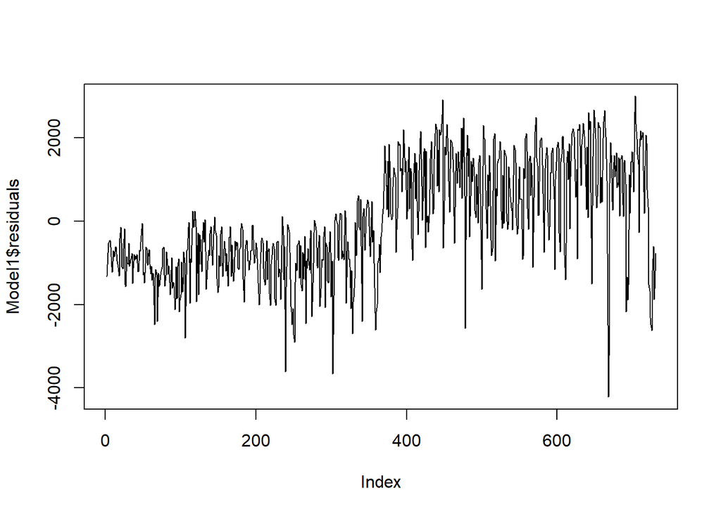

```r
# Plot the residuals of the linear regression model with month as a factor
plot(Model1$residuals, type="l")
```

```r
# Fit a quadratic trend model using tslm function
Model2 <- tslm(variable_bike_share ~ trend + I(trend^2))
# The I(trend^2) term adds a quadratic term to the model
print(summary(Model2))
```

```
##
## Call:
## tslm(formula = variable_bike_share ~ trend + I(trend^2))
##
## Residuals:
##     Min      1Q  Median      3Q     Max
## -4825.7  -597.9    41.9   809.0  2147.2
##
## Coefficients:
##               Estimate Std. Error t value Pr(>|t|)
## (Intercept)  1.331e+03  1.279e+02  10.412  < 2e-16 ***
## trend        9.303e+00  8.067e-01  11.531  < 2e-16 ***
## I(trend^2)  -6.050e-03  1.067e-03  -5.669 2.07e-08 ***
## ---
## Signif. codes:  0 '***' 0.001 '**' 0.01 '*' 0.05 '.' 0.1 ' ' 1
##
## Residual standard error: 1149 on 728 degrees of freedom
## Multiple R-squared:  0.459,  Adjusted R-squared:  0.4575
## F-statistic: 308.8 on 2 and 728 DF,  p-value: < 2.2e-16
```